# Preliminary Data Exploration-1

## **Preliminary Data Exploration**

Explore the data set before determining the project topic. The goal of the preliminary data exploration is to explore interesting aspects of the data set, and develop potential project ideas.

The preliminary data exploration step aim to answer the following questions:

a) Can you identify any limitations or distortions of the data?

b) What is the most popular name of all time? (Of either gender.)

c) What is the most gender ambiguous name in 2013? 1945?

d) Of the names represented in the data, find the name that has had the largest percentage increase in popularity since 1980. Largest decrease?

e) Can you identify names that may have had an even larger increase or decrease in popularity?

```python
#load packages
%matplotlib inline
import pandas as pd
import numpy as np
import seaborn as sns
import matplotlib.pyplot as plt
import math
```

```python
#load in data
df = pd.read_csv('/Users/zz/Downloads/CS109A/Project/output/NationalNames.csv')
```

### Basic Data Description

```python
df.head(5)
```

|  | Id | Name | Year | Gender | Count |
| --- | --- | --- | --- | --- | --- |
| 0 | 1 | Mary | 1880 | F | 7065 |
| 1 | 2 | Anna | 1880 | F | 2604 |
| 2 | 3 | Emma | 1880 | F | 2003 |
| 3 | 4 | Elizabeth | 1880 | F | 1939 |
| 4 | 5 | Minnie | 1880 | F | 1746 |

```python
#continous variable summary statistics
df[['Year','Count']].describe()
```

|  | Year | Count |
| --- | --- | --- |
| count | 1825433.000000 | 1825433.000000 |
| mean | 1972.619783 | 184.687921 |
| std | 33.528912 | 1566.710979 |
| min | 1880.000000 | 5.000000 |
| 25% | 1949.000000 | 7.000000 |
| 50% | 1982.000000 | 12.000000 |
| 75% | 2001.000000 | 32.000000 |
| max | 2014.000000 | 99680.000000 |

### Data Exploration

**Identify any limitation or distortions of the data**:

```python
df.isnull().sum()
```

```
Id        0
Name      0
Year      0
Gender    0
Count     0
dtype: int64
```

```python
df_count = df.groupby(['Year']).agg(['count'])
```

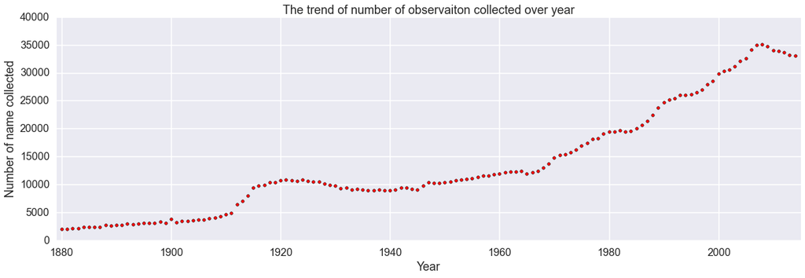

```python
plt.figure(figsize=(20, 6))
plt.scatter(x = df_count.index , y = df_count['Count'], c = 'r')
#plt.xticks(range(0, len(df_count.index)),df_count.index, rotation = '90', fontsize = 10)
plt.xlabel("Year")
plt.xlim([1879, 2015])
plt.ylabel("Number of name collected")
plt.title("The trend of number of observaiton collected over year", fontsize = 18)
plt.show()
```

```python
df2 = pd.read_csv('/Users/zz/Downloads/CS109A/Project/output/StateNames.csv')
```

```python
df2[['Year','Count']].describe()
```

|  | Year | Count |
| --- | --- | --- |
| count | 5.647426e+06 | 5.647426e+06 |
| mean | 1.972392e+03 | 5.292381e+01 |
| std | 2.957390e+01 | 1.808100e+02 |
| min | 1.910000e+03 | 5.000000e+00 |
| 25% | 1.949000e+03 | 7.000000e+00 |
| 50% | 1.977000e+03 | 1.300000e+01 |
| 75% | 1.999000e+03 | 3.400000e+01 |
| max | 2.014000e+03 | 1.002300e+04 |

```python
df2.head()
```

|  | Id | Name | Year | Gender | State | Count |
| --- | --- | --- | --- | --- | --- | --- |
| 0 | 1 | Mary | 1910 | F | AK | 14 |
| 1 | 2 | Annie | 1910 | F | AK | 12 |
| 2 | 3 | Anna | 1910 | F | AK | 10 |
| 3 | 4 | Margaret | 1910 | F | AK | 8 |
| 4 | 5 | Helen | 1910 | F | AK | 7 |

```python
df.groupby(['Year']).describe()
```

| Year |  | Count | Id |
| --- | --- | --- | --- |
| 1880 | count | 2000.000000 | 2.000000e+03 |
|  | mean | 100.742000 | 1.000500e+03 |
|  | std | 466.108732 | 5.774946e+02 |
|  | min | 5.000000 | 1.000000e+00 |
|  | 25% | 7.000000 | 5.007500e+02 |
|  | 50% | 13.000000 | 1.000500e+03 |
|  | 75% | 41.250000 | 1.500250e+03 |
|  | max | 9655.000000 | 2.000000e+03 |
| 1881 | count | 1935.000000 | 1.935000e+03 |
|  | mean | 99.586047 | 2.968000e+03 |
|  | std | 438.361938 | 5.587307e+02 |
|  | min | 5.000000 | 2.001000e+03 |
|  | 25% | 7.000000 | 2.484500e+03 |
|  | 50% | 13.000000 | 2.968000e+03 |
|  | 75% | 42.000000 | 3.451500e+03 |
|  | max | 8769.000000 | 3.935000e+03 |
| 1882 | count | 2127.000000 | 2.127000e+03 |
|  | mean | 104.155148 | 4.999000e+03 |
|  | std | 468.476439 | 6.141563e+02 |
|  | min | 5.000000 | 3.936000e+03 |
|  | 25% | 7.000000 | 4.467500e+03 |
|  | 50% | 13.000000 | 4.999000e+03 |
|  | 75% | 42.500000 | 5.530500e+03 |
|  | max | 9557.000000 | 6.062000e+03 |
| 1883 | count | 2084.000000 | 2.084000e+03 |
|  | mean | 104.102687 | 7.104500e+03 |
|  | std | 448.158853 | 6.017433e+02 |
|  | min | 5.000000 | 6.063000e+03 |
|  | 25% | 7.000000 | 6.583750e+03 |
|  | 50% | 13.000000 | 7.104500e+03 |
| ... | ... | ... | ... |
| 2011 | std | 686.427147 | 9.777282e+03 |
|  | min | 5.000000 | 1.691634e+06 |
|  | 25% | 7.000000 | 1.700101e+06 |
|  | 50% | 11.000000 | 1.708568e+06 |
|  | 75% | 29.000000 | 1.717035e+06 |
|  | max | 21816.000000 | 1.725502e+06 |
| 2012 | count | 33684.000000 | 3.368400e+04 |
|  | mean | 108.162214 | 1.742344e+06 |
|  | std | 680.646117 | 9.723878e+03 |
|  | min | 5.000000 | 1.725503e+06 |
|  | 25% | 7.000000 | 1.733924e+06 |
|  | 50% | 11.000000 | 1.742344e+06 |
|  | 75% | 30.000000 | 1.750765e+06 |
|  | max | 22267.000000 | 1.759186e+06 |
| 2013 | count | 33203.000000 | 3.320300e+04 |
|  | mean | 109.231154 | 1.775788e+06 |
|  | std | 677.436909 | 9.585025e+03 |
|  | min | 5.000000 | 1.759187e+06 |
|  | 25% | 7.000000 | 1.767488e+06 |
|  | 50% | 11.000000 | 1.775788e+06 |
|  | 75% | 29.000000 | 1.784088e+06 |
|  | max | 21147.000000 | 1.792389e+06 |
| 2014 | count | 33044.000000 | 3.304400e+04 |
|  | mean | 111.068605 | 1.808912e+06 |
|  | std | 678.376693 | 9.539125e+03 |
|  | min | 5.000000 | 1.792390e+06 |
|  | 25% | 7.000000 | 1.800651e+06 |
|  | 50% | 11.000000 | 1.808912e+06 |
|  | 75% | 30.000000 | 1.817172e+06 |
|  | max | 20799.000000 | 1.825433e+06 |

1080 rows × 2 columns

The years included in the national data set and the state data set do not match up. The national data begins in 1880 while the state data begins in 1910. There is a different number of names for each row and for each state because the criteria used for including the name in the data set is that the name has to have a minimum of five occurrences. Thus we cannot assume that the number of names in the data set will be the same for any two years.

**Gender Irregularity**

The next issue that we are digging into is that whether there are some female or male names appear irregularly in the dataset. For example, we want to check whether there are some names that have the high frequency among the female population but also has very high frequency in the male population. This time we just did a very early stage data exploration. We took 1880 as an example and calculated the frequency of each name in 1880 and calculated the frequency of each names appeared among female and male populations. And take the females as an example. We found that there seems to be no obvious irregular names appears. Because the names appear to have high frequencies among females all have very low frequencies on males. The method we want to check whether the name should be a female name or a male name is to draw the number of the name appears versus the time in males and females. Take the name “Olivia” as an example. This name does not seem to have very high frequency among female names. But as time goes by, the number of females with name “Olivia” increased a lot but very little increase in males. So we can conclude that “Olivia” is the common name among female but not a common name among males. Please refer to fig 2 and fig 3. But if there does appear to be some names that has both high frequencies in males and females, we should think that whether this name is a common name that could be used by both females and males or it may be due to the mislabel of the gender categories.

```python
#count the frequency of name for each gender group in each year
freq_df = df.groupby(['Year','Gender'])
```

```python
#total number of count in each gender group for each year
freq_df['Count'].sum().head(6)
```

```
Year  Gender
1880  F          90993
      M         110491
1881  F          91954
      M         100745
1882  F         107850
      M         113688
Name: Count, dtype: int64
```

```python
#count the frequency of each name in each year and gender
freq_df['Count'].transform(lambda x: 100. * x / x.sum()).head(5)
```

```
0    7.764334
1    2.861759
2    2.201268
3    2.130933
4    1.918829
Name: Count, dtype: float64
```

```python
df.loc[:, 'Freq'] = freq_df['Count'].transform(lambda x: 100. * x / x.sum())
df.head(10)
```

|  | Id | Name | Year | Gender | Count | Freq |
| --- | --- | --- | --- | --- | --- | --- |
| 0 | 1 | Mary | 1880 | F | 7065 | 7.764334 |
| 1 | 2 | Anna | 1880 | F | 2604 | 2.861759 |
| 2 | 3 | Emma | 1880 | F | 2003 | 2.201268 |
| 3 | 4 | Elizabeth | 1880 | F | 1939 | 2.130933 |
| 4 | 5 | Minnie | 1880 | F | 1746 | 1.918829 |
| 5 | 6 | Margaret | 1880 | F | 1578 | 1.734199 |
| 6 | 7 | Ida | 1880 | F | 1472 | 1.617707 |
| 7 | 8 | Alice | 1880 | F | 1414 | 1.553966 |
| 8 | 9 | Bertha | 1880 | F | 1320 | 1.450661 |
| 9 | 10 | Sarah | 1880 | F | 1288 | 1.415493 |

```python
#fine the frequency of name in each year from female group
df_f = df.set_index(["Year","Name"]).loc[df_mf.Gender == "F",["Freq"]]
#find the frequency of name in each year from male group
df_m = df.set_index(["Year","Name"]).loc[df_mf.Gender == "M",["Freq"]]
```

```python
#combine the above result together
df_freq = pd.concat([df_f, df_m], axis = 1, join = 'inner')
df_freq.columns = ['Freq_F', 'Freq_M']
df_freq.head(10)
```

| Year | Name | Freq_F | Freq_M |
| --- | --- | --- | --- |
| 1880 | Addie | 0.301122 | 0.007240 |
|  | Allie | 0.115393 | 0.028057 |
|  | Alma | 0.304419 | 0.012671 |
|  | Alpha | 0.028574 | 0.005430 |
|  | Alva | 0.018683 | 0.063354 |
|  | Anna | 2.861759 | 0.010861 |
|  | Annie | 1.382524 | 0.005430 |
|  | Arthur | 0.005495 | 1.447177 |
|  | Artie | 0.031871 | 0.004525 |
|  | Augusta | 0.165947 | 0.004525 |

```python
#compute the ratio of frequency
df_freq['Freqratio_FToM'] = df_freq.Freq_F / df_freq.Freq_M
```

```python
df_freq.head(5)
```

| Year | Name | Freq_F | Freq_M | Freqratio_FToM |
| --- | --- | --- | --- | --- |
| 1880 | Addie | 0.301122 | 0.007240 | 41.589098 |
|  | Allie | 0.115393 | 0.028057 | 4.112885 |
|  | Alma | 0.304419 | 0.012671 | 24.025401 |
|  | Alpha | 0.028574 | 0.005430 | 5.261881 |
|  | Alva | 0.018683 | 0.063354 | 0.294897 |

**The names that mostly likely to be Female's name for that year**

```python
df_freq.sort(['Freqratio_FToM'], ascending = False).head(10)
```

| Year | Name | Freq_F | Freq_M | Freqratio_FToM |
| --- | --- | --- | --- | --- |
| 2000 | Olivia | 0.708255 | 0.000306 | 2316.472686 |
| 2007 | Samantha | 0.618420 | 0.000290 | 2135.753136 |
| 2009 | Sophia | 0.923387 | 0.000455 | 2030.737348 |
| 2014 | Evelyn | 0.491414 | 0.000263 | 1868.723856 |
|  | Emma | 1.175899 | 0.000631 | 1863.187772 |
| 2006 | Anna | 0.452893 | 0.000244 | 1859.013049 |
| 2011 | Mia | 0.656516 | 0.000370 | 1775.621309 |
| 1997 | Abigail | 0.553338 | 0.000318 | 1737.592438 |
| 2011 | Ella | 0.546051 | 0.000317 | 1722.999453 |
| 1999 | Brittany | 0.448034 | 0.000261 | 1719.384630 |

**Take a look the frequency of 'Olivia' as a female name how it changes over time (selected every 5 years)**

```python
Olivia = df[(df['Name']=='Olivia')&(df['Gender'] == 'F')]
Olivia = Olivia[Olivia['Year']%5 == 0]
```

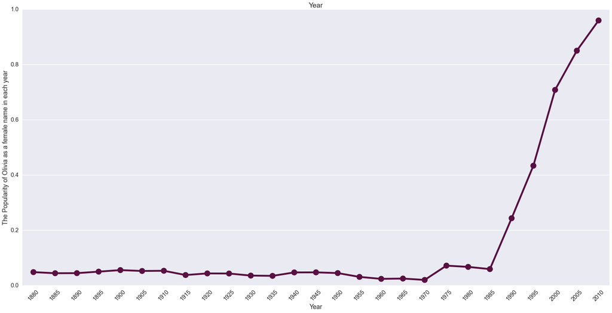

```python
plt.figure(figsize = (12, 6))
sns.set_context('poster')
sns.set_style('darkgrid')
g = sns.PairGrid(Olivia, y_vars="Freq",
                 x_vars=["Year"],
                 size=12, aspect=2)
g.map(sns.pointplot, color=sns.xkcd_rgb["plum"])
g.set(ylim=(0, 1))
g.set(ylabel = 'The Popularity of Olivia as a female name in each year')
g.set(title = 'Year')
sns.despine(fig=g.fig, left=True)
xt = plt.xticks(rotation=45)
```

```python
Olivia = df[(df['Name']=='Olivia')&(df['Gender'] == 'M')]
Olivia = Olivia[Olivia['Year']%5 == 0]
```

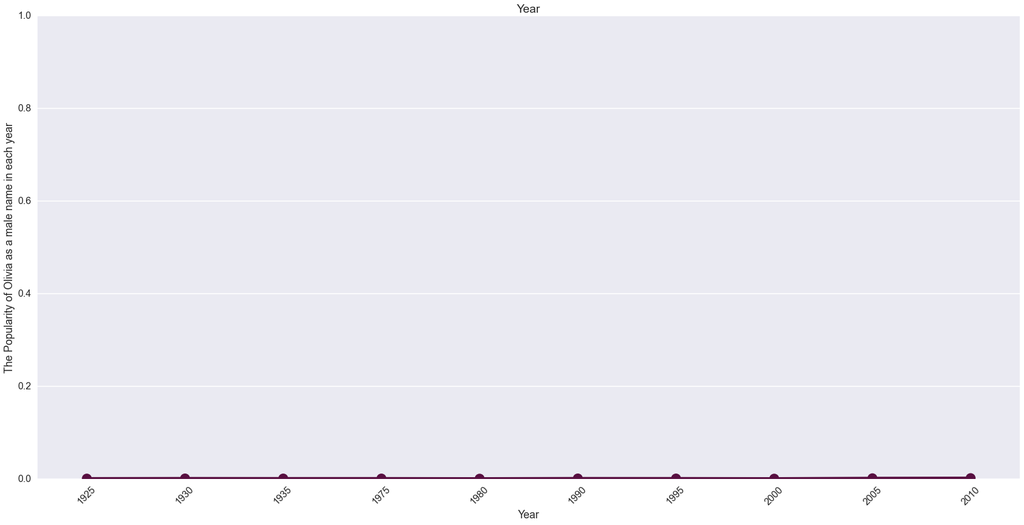

```python
plt.figure(figsize = (12, 6))
sns.set_context('poster')
sns.set_style('darkgrid')
g = sns.PairGrid(Olivia, y_vars="Freq",
                 x_vars=["Year"],
                 size=12, aspect=2)
g.map(sns.pointplot, color=sns.xkcd_rgb["plum"])
g.set(ylim=(0, 1))
g.set(ylabel = 'The Popularity of Olivia as a male name in each year')
g.set(title = 'Year')
sns.despine(fig=g.fig, left=True)
xt = plt.xticks(rotation=45)
```

Although Olivia is not a top popular name among female names (the frequency of it appear in the female group is not very high), it is a more likely to be a female name instead of male name over years.

**The names that mostly likely to be Male's name for that year**

```python
df_freq.sort(['Freqratio_FToM'], ascending = True).head(10)
```

| Year | Name | Freq_F | Freq_M | Freqratio_FToM |
| --- | --- | --- | --- | --- |
| 2014 | Joseph | 0.000339 | 0.630859 | 0.000538 |
| 2013 | Luke | 0.000286 | 0.507371 | 0.000565 |
| 2011 | Samuel | 0.000342 | 0.597920 | 0.000572 |
| 2010 | Isaac | 0.000282 | 0.488074 | 0.000578 |
| 2014 | Lucas | 0.000396 | 0.635224 | 0.000623 |
| 2011 | Jack | 0.000285 | 0.431802 | 0.000660 |
| 2012 | Lucas | 0.000399 | 0.565519 | 0.000706 |
| 2010 | Luke | 0.000338 | 0.461373 | 0.000734 |
| 2013 | Isaac | 0.000401 | 0.535115 | 0.000749 |
| 1950 | Peter | 0.000350 | 0.467254 | 0.000750 |

**Popular Name**

Most popular names Then we look the most popular names from 1880 to 2014. Regardless of gender, the most popular names are James and John. For females, the most popular names are Mary and Elizabeth. For males, the top 2 are also James and John. Clearly, there is a distinction between female popular names and male popular names. But surprisingly, the populars name of all gender is pretty similar to the popular names of male. It is probably because we have more males than female in our data set.

```python
popular_df = df.groupby('Name').agg({'Count':'sum'}).sort(['Count'],ascending=False)
popular_df = popular_df.reset_index()
popular_df.head(10)
```

|  | Name | Count |
| --- | --- | --- |
| 0 | James | 5129096 |
| 1 | John | 5106590 |
| 2 | Robert | 4816785 |
| 3 | Michael | 4330805 |
| 4 | Mary | 4130441 |
| 5 | William | 4071368 |
| 6 | David | 3590557 |
| 7 | Joseph | 2580687 |
| 8 | Richard | 2564867 |
| 9 | Charles | 2376700 |

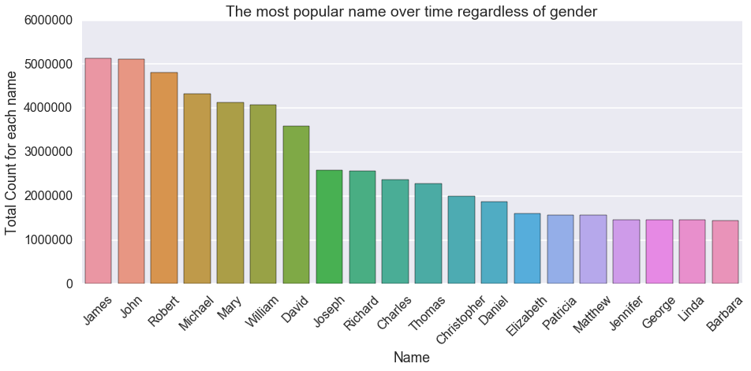

```python
plt.figure(figsize = (15, 6))
sns.set_context('poster')
sns.set_style('darkgrid')
g = sns.barplot(x='Name', y='Count', data =popular_df.head(20), ax = None, ci=None)
# Draw a seaborn pointplot onto each Axes
g.set(ylabel = 'Total Count for each name')
g.set(xlabel = 'Name')
g.set(title = 'The most popular name over time regardless of gender')
xt = plt.xticks(rotation=45)
```

**Popular Name across all time: Female Only**

```python
popular_female = df[df['Gender']=='F'].groupby('Name').agg({'Count':'sum'}).sort(['Count'],ascending=False)
popular_female = popular_female.reset_index()
popular_female.head(10)
```

|  | Name | Count |
| --- | --- | --- |
| 0 | Mary | 4115282 |
| 1 | Elizabeth | 1601128 |
| 2 | Patricia | 1570567 |
| 3 | Jennifer | 1462742 |
| 4 | Linda | 1450843 |
| 5 | Barbara | 1432944 |
| 6 | Margaret | 1240006 |
| 7 | Susan | 1120469 |
| 8 | Dorothy | 1105680 |
| 9 | Sarah | 1060643 |

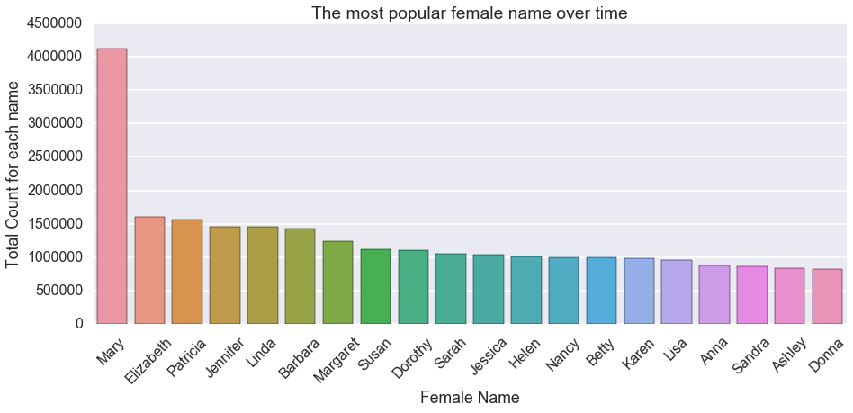

```python
plt.figure(figsize = (15, 6))
sns.set_context('poster')
sns.set_style('darkgrid')
g = sns.barplot(x='Name', y='Count', data =popular_female.head(20), ax = None, ci=None)
# Draw a seaborn pointplot onto each Axes
g.set(ylabel = 'Total Count for each name')
g.set(xlabel = 'Female Name')
g.set(title = 'The most popular female name over time')
xt = plt.xticks(rotation=45)
```

**Popular Name across all time: Male Only**

```python
popular_male = df[df['Gender']=='M'].groupby('Name').agg({'Count':'sum'}).sort(['Count'],ascending=False)
popular_male = popular_male.reset_index()
popular_male.head(10)
```

|  | Name | Count |
| --- | --- | --- |
| 0 | James | 5105919 |
| 1 | John | 5084943 |
| 2 | Robert | 4796695 |
| 3 | Michael | 4309198 |
| 4 | William | 4055473 |
| 5 | David | 3577704 |
| 6 | Joseph | 2570095 |
| 7 | Richard | 2555330 |
| 8 | Charles | 2364332 |
| 9 | Thomas | 2283080 |

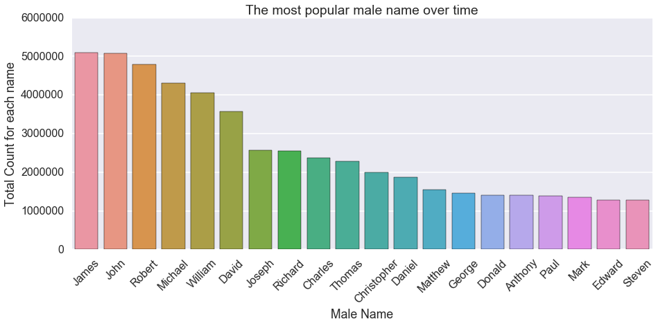

```python
plt.figure(figsize = (15, 6))
sns.set_context('poster')
sns.set_style('darkgrid')
g = sns.barplot(x='Name', y='Count', data =popular_male.head(20), ax = None, ci=None)
# Draw a seaborn pointplot onto each Axes
g.set(ylabel = 'Total Count for each name')
g.set(xlabel = 'Male Name')
g.set(title = 'The most popular male name over time')
xt = plt.xticks(rotation=45)
```

**Most Ambigous Name across all the time**: We define the ambigous as "cannot distinguish the gender by name". Thus, if the name having high counts in both gender (50-50 chance in both gender), we regard it as high ambiguity. If the name is used only for male or only for female, we regard it as low ambiguity. If order to find the ambiguity accurately, we would like to filter out the name with too low number of total count. For example, if there is a name have only two count, one for female and one for male. Based on the criteria we set before, we will regard it as high ambigous name, but only two count may not sufficient to show the name is a ambigous name.

Here, we measure the ambiguity by calculating the ambiguity ratio. We then look at the ambiguity of names in 2013 and 1945. The most gender ambiguous name is Artie in 1945 and Arie in 2013.

```python
df = pd.read_csv('/Users/zz/Downloads/CS109A/Project/output/NationalNames.csv')
```

```python
#number of count for each name in the two gender groups
name_gender_count = df.groupby(['Name','Gender']).agg({'Count':'sum'})
```

```python
name_count = df.groupby(['Name']).agg({'Count':'sum'})
```

```python
name_gender_count = name_gender_count.reset_index()
```

```python
name_count = name_count.reset_index()
```

```python
combined = name_gender_count.merge(name_count, on = 'Name')
#find out the name from both gender
both_gender = combined[combined['Count_x']!=combined['Count_y']]
both_gender.head(6)
```

|  | Name | Gender | Count_x | Count_y |
| --- | --- | --- | --- | --- |
| 7 | Aaden | F | 5 | 3920 |
| 8 | Aaden | M | 3915 | 3920 |
| 16 | Aadi | F | 16 | 683 |
| 17 | Aadi | M | 667 | 683 |
| 35 | Aadyn | F | 16 | 403 |
| 36 | Aadyn | M | 387 | 403 |

```python
#would like to only include the name have total count more than 100
both_gender = both_gender[both_gender['Count_y'] >= 100]
```

```python
both_gender.loc[:, 'gender_ratio'] = both_gender['Count_x']/both_gender['Count_y']
both_gender.head(6)
```

|  | Name | Gender | Count_x | Count_y | gender_ratio |
| --- | --- | --- | --- | --- | --- |
| 7 | Aaden | F | 5 | 3920 | 0.001276 |
| 8 | Aaden | M | 3915 | 3920 | 0.998724 |
| 16 | Aadi | F | 16 | 683 | 0.023426 |
| 17 | Aadi | M | 667 | 683 | 0.976574 |
| 35 | Aadyn | F | 16 | 403 | 0.039702 |
| 36 | Aadyn | M | 387 | 403 | 0.960298 |

```python
both_gender.loc[:, 'ambig_ratio'] = 0.5 - abs(both_gender['gender_ratio'] - 0.5)
both_gender.head(10)
```

|  | Name | Gender | Count_x | Count_y | gender_ratio | ambig_ratio |
| --- | --- | --- | --- | --- | --- | --- |
| 7 | Aaden | F | 5 | 3920 | 0.001276 | 0.001276 |
| 8 | Aaden | M | 3915 | 3920 | 0.998724 | 0.001276 |
| 16 | Aadi | F | 16 | 683 | 0.023426 | 0.023426 |
| 17 | Aadi | M | 667 | 683 | 0.976574 | 0.023426 |
| 35 | Aadyn | F | 16 | 403 | 0.039702 | 0.039702 |
| 36 | Aadyn | M | 387 | 403 | 0.960298 | 0.039702 |
| 106 | Aalijah | F | 107 | 262 | 0.408397 | 0.408397 |
| 107 | Aalijah | M | 155 | 262 | 0.591603 | 0.408397 |
| 115 | Aaliyah | F | 69833 | 69917 | 0.998799 | 0.001201 |
| 116 | Aaliyah | M | 84 | 69917 | 0.001201 | 0.001201 |

```python
#the maximum ambigious ratio is 0.5
#we would like to sort the ambigious ratio by the ratio and the total count
#so the highest one will have the name 50-50 chance for male and female, also have high number of count
sort_ambig = both_gender[(both_gender['ambig_ratio'] > 0.4)].sort(['ambig_ratio','Count_y', 'Name'], ascending=False)
sort_ambig = sort_ambig[['Name', 'Gender', 'Count_x', 'Count_y', 'ambig_ratio']]
```

```python
sort_ambig.columns = ['Name', 'Gender', 'Count_Each', 'Total_Count', 'Ambigous_Ratio']
sort_ambig.head(6)
```

|  | Name | Gender | Count_Each | Total_Count | Ambigous_Ratio |
| --- | --- | --- | --- | --- | --- |
| 94851 | Tkai | F | 72 | 144 | 0.500000 |
| 94852 | Tkai | M | 72 | 144 | 0.500000 |
| 54981 | Krishna | F | 1713 | 3428 | 0.499708 |
| 54982 | Krishna | M | 1715 | 3428 | 0.499708 |
| 57136 | Laray | F | 361 | 723 | 0.499308 |
| 57137 | Laray | M | 362 | 723 | 0.499308 |

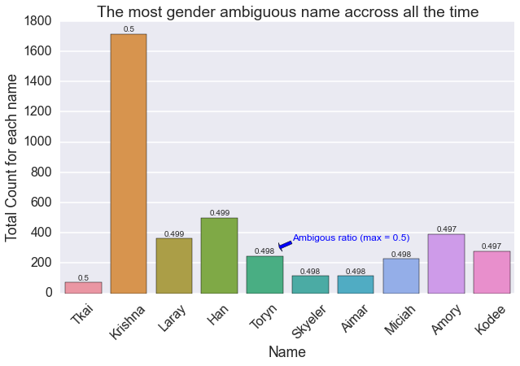

```python
plt.figure(figsize = (10, 6))
sns.set_context('poster')
sns.set_style('darkgrid')
g = sns.barplot(x='Name', y='Count_Each', data =sort_ambig.head(20), ax = None, ci=None)
# Draw a seaborn pointplot onto each Axes
labels = ["{}".format(round(sort_ambig['Ambigous_Ratio'][0:20].values[i],3)) for i in range(0, 20, 2)]
rects = g.patches
for rect, label in zip(rects, labels):
    height = rect.get_height()
    g.text(rect.get_x() + rect.get_width()/2, height + 5, label, ha='center', va='bottom', fontsize = 10)
g.set(ylabel = 'Total Count for each name')
g.set(xlabel = 'Name')
g.set(title = 'The most gender ambiguous name accross all the time')

g.annotate('Ambigous ratio (max = 0.5)', xy=(4.3, 300), xytext=(4.6, 350),
            arrowprops=dict(facecolor='blue', shrink=0.05), fontsize = 12, color = 'b')
xt = plt.xticks(rotation=45)
```

**Most gender ambiguous name in 2013**

```python
def ambiguous(year):
    name_gender_count_year = df[df['Year']==year]
    name_count_year = df[df['Year']==year].groupby(['Name']).agg({'Count':'sum'})
    name_count_year = name_count_year.reset_index()
    comb_year = name_gender_count_year.merge(name_count_year, on = 'Name')
    both_gender_year = comb_year[comb_year['Count_x']!=comb_year['Count_y']]
    both_gender_year = both_gender_year[both_gender_year['Count_y'] >= 100]
    both_gender_year.loc[:, 'gender_ratio'] = both_gender_year['Count_x']/both_gender_year['Count_y']
    both_gender_year.loc[:, 'ambig_ratio'] = 0.5 - abs(both_gender_year['gender_ratio'] - 0.5)
    sort_ambig_year = both_gender_year.sort(['ambig_ratio','Count_y', 'Name'], ascending=False)
    sort_ambig_year = sort_ambig_year[['Name', 'Gender', 'Count_x', 'Count_y', 'ambig_ratio']]
    sort_ambig_year.columns = ['Name', 'Gender', 'Count_Each', 'Total_Count', 'Ambigous_Ratio']
    return sort_ambig_year
```

```python
ambiguous2013 = ambiguous(2013)
```

```python
ambiguous2013.head(10)
```

|  | Name | Gender | Count_Each | Total_Count | Ambigous_Ratio |
| --- | --- | --- | --- | --- | --- |
| 2873 | Arie | F | 79 | 158 | 0.500000 |
| 2874 | Arie | M | 79 | 158 | 0.500000 |
| 2522 | Ryley | F | 96 | 193 | 0.497409 |
| 2523 | Ryley | M | 97 | 193 | 0.497409 |
| 2610 | Salem | F | 91 | 184 | 0.494565 |
| 2611 | Salem | M | 93 | 184 | 0.494565 |
| 2689 | Teegan | F | 87 | 176 | 0.494318 |
| 2690 | Teegan | M | 89 | 176 | 0.494318 |
| 814 | Milan | F | 475 | 961 | 0.494277 |
| 815 | Milan | M | 486 | 961 | 0.494277 |

```python
ambiguous(1945).head(10)
```

|  | Name | Gender | Count_Each | Total_Count | Ambigous_Ratio |
| --- | --- | --- | --- | --- | --- |
| 1351 | Artie | F | 60 | 120 | 0.500000 |
| 1352 | Artie | M | 60 | 120 | 0.500000 |
| 1211 | Leigh | F | 74 | 152 | 0.486842 |
| 1212 | Leigh | M | 78 | 152 | 0.486842 |
| 1006 | Lavern | F | 112 | 232 | 0.482759 |
| 1007 | Lavern | M | 120 | 232 | 0.482759 |
| 915 | Toby | F | 133 | 256 | 0.480469 |
| 916 | Toby | M | 123 | 256 | 0.480469 |
| 1464 | Theo | F | 53 | 101 | 0.475248 |
| 1465 | Theo | M | 48 | 101 | 0.475248 |

**Largest Increasing**

**Name with largest percentage increase since 1980**

```python
df_1980 = df[df['Year']>=1980]
```

```python
count_name_year = df_1980.groupby(['Name','Year']).agg({'Count':'sum'}).reset_index()
count_year = df_1980.groupby(['Year']).agg({'Count':'sum'}).reset_index()
count_1980 = count_name_year.merge(count_year, on = 'Year')
count_1980.loc[:, 'name_percentage'] = count_1980['Count_x']/count_1980['Count_y']
```

```python
count_1980 = count_1980[['Name','Year','name_percentage']]
count_1980.head()
```

|  | Name | Year | name_percentage |
| --- | --- | --- | --- |
| 0 | Aaban | 2007 | 0.000001 |
| 1 | Aadam | 2007 | 0.000002 |
| 2 | Aadan | 2007 | 0.000002 |
| 3 | Aadarsh | 2007 | 0.000003 |
| 4 | Aaden | 2007 | 0.000039 |

```python
count_1980_change = count_1980.pivot(index='Name', columns='Year', values='name_percentage')
count_1980_change.loc[:, 'difference'] = count_1980_change[2014] - count_1980_change[1980]
```

**The names that has been increased largest percentage of popularity from 1980 to 2014**

```python
count_1980_change = count_1980_change.sort(['difference'], ascending = False)
count_1980_change[['difference']].head(10)
```

| Year Name | difference |
| --- | --- |
| Emma | 0.005515 |
| Olivia | 0.005041 |
| Liam | 0.004974 |
| Noah | 0.004974 |
| Sophia | 0.004856 |
| Isabella | 0.004613 |
| Mason | 0.004580 |
| Ava | 0.004218 |
| Ethan | 0.004056 |
| Logan | 0.003758 |

**The names that has been decreased largest percentage of popularity from 1980 to 2014**

```python
count_1980_change = count_1980_change.sort(['difference'], ascending = True)
count_1980_change[['difference']].head(10)
```

| Year Name | difference |
| --- | --- |
| Jennifer | -0.016600 |
| Michael | -0.015913 |
| Jason | -0.012575 |
| Christopher | -0.011540 |
| Amanda | -0.010142 |
| Jessica | -0.009401 |
| David | -0.008961 |
| Melissa | -0.008817 |
| Robert | -0.008234 |
| Brian | -0.007705 |

**The names that has largest percentage change of popularity over years**

```python
count_1980 = count_1980.pivot(index='Name', columns='Year', values='name_percentage')
```

```python
count_1980.loc[:,'row_max'] = count_1980.max(axis=1, skipna = True)
count_1980.loc[:,'row_min'] = count_1980.min(axis=1, skipna = True)
```

```python
count_1980.loc[:,'year_max'] = count_1980.idxmax(axis=1, skipna = True)
count_1980.loc[:,'year_min'] = count_1980.idxmin(axis=1, skipna = True)
```

```python
count_1980.loc[count_1980['year_max'] < count_1980['year_min'],'Change_dire'] = count_1980['row_min'] - count_1980['row_max']
count_1980.loc[count_1980['year_max'] > count_1980['year_min'],'Change_dire'] = count_1980['row_max'] - count_1980['row_min']
```

```python
count_1980.loc[:,'lagest_difference'] = count_1980['row_max'] - count_1980['row_min']
count_1980_magnitude = count_1980[['row_max','row_min','lagest_difference', 'Change_dire']]
```

```python
count_1980_magnitude.head(2)
```

| Year Name | row_max | row_min | lagest_difference | Change_dire |
| --- | --- | --- | --- | --- |
| Aaban | 0.000004 | 0.000001 | 0.000003 | 0.000003 |
| Aabha | 0.000002 | 0.000001 | 0.000001 | 0.000001 |

**Names that have had an ever larger increase in popularity**

```python
largest_increase = count_1980_magnitude.sort(['Change_dire'], ascending = False).head(10)
largest_increase = largest_increase.reset_index()
largest_increase = largest_increase[['Name', 'row_max','row_min', 'Change_dire']]
largest_increase.columns = ['Name', 'Max_popularity', 'Min_Popularity', 'Percentage_Increase']
largest_increase.head(10)
```

|  | Name | Max_popularity | Min_Popularity | Percentage_Increase |
| --- | --- | --- | --- | --- |
| 0 | Tyler | 0.008485 | 0.000779 | 0.007706 |
| 1 | Taylor | 0.007683 | 0.000248 | 0.007435 |
| 2 | Jacob | 0.009809 | 0.002490 | 0.007320 |
| 3 | Austin | 0.007124 | 0.000348 | 0.006775 |
| 4 | Isabella | 0.006215 | 0.000009 | 0.006206 |
| 5 | Madison | 0.005958 | 0.000006 | 0.005952 |
| 6 | Sophia | 0.006117 | 0.000186 | 0.005930 |
| 7 | Emma | 0.005986 | 0.000154 | 0.005831 |
| 8 | Hannah | 0.006115 | 0.000357 | 0.005759 |
| 9 | Ethan | 0.005928 | 0.000170 | 0.005758 |

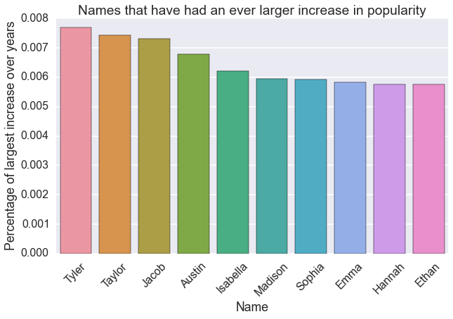

```python
plt.figure(figsize = (10, 6))
sns.set_context('poster')
sns.set_style('darkgrid')
g = sns.barplot(x='Name', y='Percentage_Increase', data =largest_increase.head(10), ax = None, ci=None)
# Draw a seaborn pointplot onto each Axes
g.set(ylabel = 'Percentage of largest increase over years')
g.set(xlabel = 'Name')
g.set(title = 'Names that have had an ever larger increase in popularity')
xt = plt.xticks(rotation=45)
```

**Names that have had an ever larger decrease in popularity**

```python
largest_decrease = count_1980_magnitude.sort(['Change_dire'], ascending = True).head(10)
largest_decrease = largest_decrease.reset_index()
largest_decrease = largest_decrease[['Name', 'row_max','row_min', 'Change_dire']]
largest_decrease.columns = ['Name', 'Max_popularity', 'Min_Popularity', 'Percentage_Decrease']
largest_decrease.head(10)
```

|  | Name | Max_popularity | Min_Popularity | Percentage_Decrease |
| --- | --- | --- | --- | --- |
| 0 | Jennifer | 0.017015 | 0.000414 | -0.016600 |
| 1 | Michael | 0.020098 | 0.004185 | -0.015913 |
| 2 | Jessica | 0.015603 | 0.000485 | -0.015119 |
| 3 | Christopher | 0.017325 | 0.002805 | -0.014520 |
| 4 | Ashley | 0.015332 | 0.000975 | -0.014357 |
| 5 | Jason | 0.014078 | 0.001503 | -0.012575 |
| 6 | Amanda | 0.011630 | 0.000284 | -0.011346 |
| 7 | Matthew | 0.014593 | 0.003494 | -0.011099 |
| 8 | Brittany | 0.009888 | 0.000175 | -0.009713 |
| 9 | Joshua | 0.011904 | 0.002937 | -0.008967 |

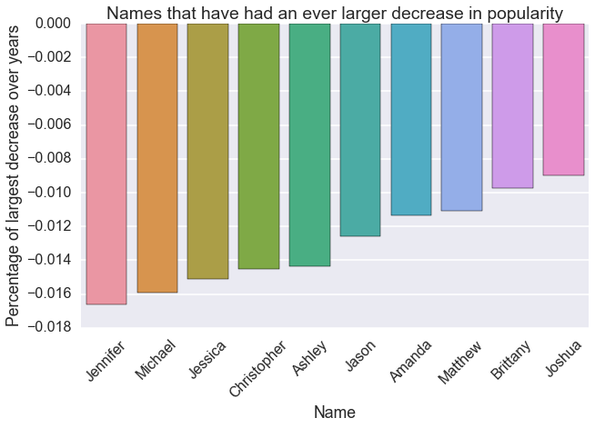

```python
plt.figure(figsize = (10, 6))
sns.set_context('poster')
sns.set_style('darkgrid')
g = sns.barplot(x='Name', y='Percentage_Decrease', data =largest_decrease.head(10), ax = None, ci=None)
# Draw a seaborn pointplot onto each Axes
g.set(ylabel = 'Percentage of largest decrease over years')
g.set(xlabel = 'Name')
g.set(title = 'Names that have had an ever larger decrease in popularity')
xt = plt.xticks(rotation=45)
```